# Time Series Analysis of Air Pollution and Health Data

## Specify Inputs

```r
datafile <- "ny.rds"
exposure <- NULL
response <- "death"
timevar <- NULL
```

## Initialization

Loading required packages.

```r
library(tsModel)
library(moments)
library(xlsx)
library(splines)
library(DSM)
library(digest)
```

## Read in Data

Read in the raw data from the file 'ny.rds'.

```r
## This function reads in .rds, .csv, or .xlsx data; returns an object of
## class 'APTSData'
d0 <- readAPTSData(datafile, response = response, exposure = exposure, timevar = timevar)
```

```
## using second column as exposure variable ('pm10tmean')
```

```
## using 'date' for 'timevar'
```

Computing hashes for data file and initial data frame.

```r
hashfile <- digest(datafile, "sha1", file = TRUE)
hashdframe <- digest(d0, "sha1")
```

## Exploratory Data Analysis

We conducted some exploratory analysis of the data.

```r
nms <- names(d0)

## Check missing data
miss.exp <- mean(is.na(d0[, d0@exposure]))
miss.response <- mean(is.na(d0[, d0@response]))
comp <- mean(complete.cases(d0))
miss <- c(response = miss.response, exposure = miss.exp, complete = comp)

## Right skewness in predictors
use <- setdiff(nms, d0@response)
skewvar <- lapply(use, function(vname) {
    try(agostino.test(d0[, vname], alt = "less"), silent = TRUE)
})
u <- !sapply(skewvar, inherits, what = "try-error")
names(skewvar) <- use

## Overdispersion
disp <- var(d0[, d0@response])/mean(d0[, d0@response])

## High leverage predictors (continuous)
use <- setdiff(nms, d0@response)
tempform <- reformulate(use)
mm <- model.matrix(tempform, as(d0, "data.frame"))
lev <- diag(mm %*% tcrossprod(solve(crossprod(mm)), mm))
highlev <- names(which(lev >= (mean(lev) * 4)))

## Response outliers [abs(std residual) > 6]
dummyform <- reformulate(sprintf("ns(%s, %d)", d0@timevar, nyears(d0[, d0@timevar]) *
    4L), d0@response)
dummy <- glm(dummyform, data = as(d0, "data.frame"), family = poisson, na.action = na.exclude)
res <- rstandard(dummy)
out <- names(which(res > 6))

eda.summ <- list(miss = miss, skew = skewvar, disp = disp, highlev = highlev,
    outlier = out)
```

Making a histogram of the response

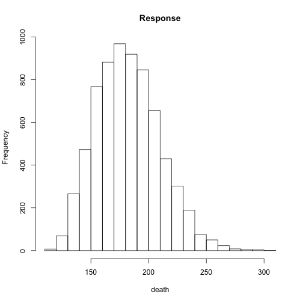

```r
yname <- d0@response
hist(d0[, yname], main = "Response", xlab = yname)
```

Making a histogram of the exposure

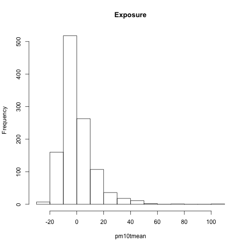

```r
xname <- d0@exposure
hist(d0[, xname], main = "Exposure", xlab = xname)
```

Bivariate plot of response and exposure

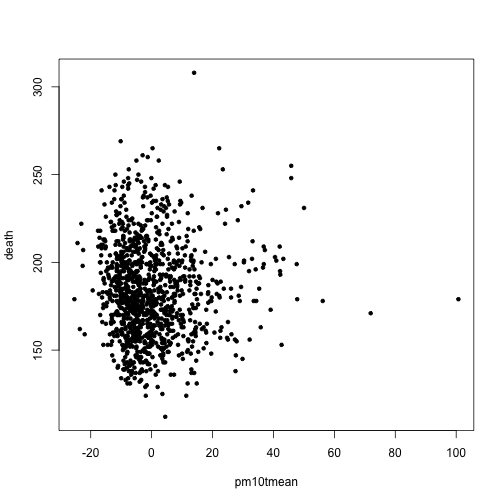

```r
plot(d0[, xname], d0[, yname], xlab = xname, ylab = yname, pch = 20)
```

## Model Building

Fitting the base model with 6 degrees of freedom per year in the dataset.

```r
nyr <- nyears(d0[, d0@timevar])  ## Compute number of years in the dataset
base <- glm(death ~ dow + ns(date, nyr * 6) + ns(tmpd, 6) + ns(rmtmpd, 6) +
    ns(dptp, 3) + ns(rmdptp, 3) + Lag(pm10tmean, 1), data = as(d0, "data.frame"),
    family = poisson)
```

Selecting the optimal degrees of freedom for the smooth function of time to adjust for unmeasured confounding. The approach is based on the methods described in Dominici et al. (2004) and Peng et al. (2006). The range of degrees of freedom per year that we search over is between 2 and 20 per year. For the spline smoother we use natural cubic splines.

```r
dfseq <- 2:20
dat <- as(d0, "data.frame")
nyr <- nyears(dat[, d0@timevar])
fnames <- attr(terms(formula(base)), "term.labels")
tpos <- grep(d0@timevar, fnames)
epos <- grep(d0@exposure, fnames)
dfseq.total <- dfseq * nyr
timeVec <- paste0("ns(", d0@timevar, ", ", dfseq.total, ")")
results <- lapply(timeVec, function(tv) {
    newFormula <- reformulate(c(tv, fnames[-c(tpos, epos)]), response = d0@exposure)
    update(base, formula = newFormula, family = gaussian)
})
aic <- sapply(results, function(x) AIC(x))
names(aic) <- dfseq
dfmin <- dfseq[which.min(aic)]
```

Optimal number of degrees of freedom *per year* for the smooth function of time is 5.

Check AIC values for selecting the degrees of freedom per year.

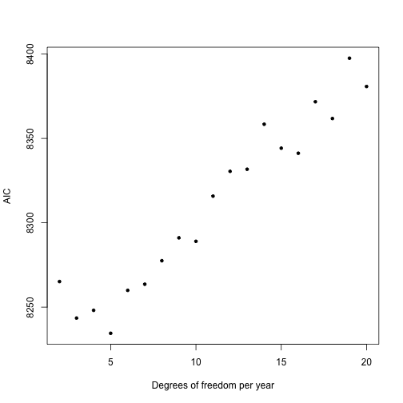

```r
plot(dfseq, aic, xlab = "Degrees of freedom per year", ylab = "AIC", pch = 20)
```

## Model Fitting

Fitting the final model.

```r
nyr <- nyears(d0[, d0@timevar])
final <- glm(death ~ dow + ns(date, nyr * dfmin) + ns(tmpd, 6) + ns(rmtmpd,
    6) + ns(dptp, 3) + ns(rmdptp, 3) + Lag(pm10tmean, 1), data = as(d0, "data.frame"),
    family = poisson)
```

```r
n <- summary(final)$df.null + 1
lev <- hatvalues(final)
cdist <- cooks.distance(final) * n
ulev <- lev > mean(lev) * 4
if (any(ulev)) {
    eda.summ$highlev <- unique(c(eda.summ$highlev, names(which(ulev))))
}
ucd <- cdist > qchisq(0.99, 1) & rank(cdist) > (n - 10)
if (any(ucd)) {
    eda.summ$outlier <- unique(c(eda.summ$outlier, names(which(ucd))))
}
```

## Results

```r
varname <- "Lag(pm10tmean, 1)"
summ.final <- summary(final)
cf <- summ.final$coefficients[varname, 1]
pval <- summ.final$coefficients[varname, 4]
ci <- confint.default(final)
```

## Sensitivity Analysis

Run sensitivity analysis with respect to the degrees of freedom for the smooth function of time.

```r
dfseq <- as.integer(dfseq)
dfseq.total <- dfseq * nyears(d0)
fnames <- attr(terms(formula(base)), "term.labels")
timevar <- d0@timevar
pos <- grep(timevar, fnames)
origTimeVar <- fnames[pos]
timeVec <- paste("ns(", timevar, ", ", dfseq.total, ")", sep = "")
results <- vector("list", length = length(dfseq.total))

for (i in seq(along = dfseq.total)) {
    newFormula <- reformulate(c(fnames[-pos], timeVec[i]), response = d0@response)
    results[[i]] <- update(final, formula = newFormula)
}
names(results) <- as.character(dfseq)
```

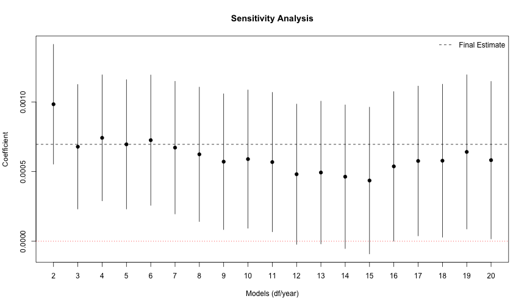

```r
exposureTerm <- grep(d0@exposure, fnames, value = TRUE)
b <- sapply(results, function(x) coef(x)[exposureTerm])
ci <- sapply(results, function(x) confint.default(x, exposureTerm))
xpts <- seq_along(results)
ypts <- b
plot(xpts, ypts, ylim = range(ci), xlab = "Models (df/year)", ylab = "Coefficient",
    pch = 19, xaxt = "n", main = "Sensitivity Analysis")
segments(xpts, ci[1, ], xpts, ci[2, ])
abline(h = coef(final)[exposureTerm], lty = 2)
abline(h = 0, lty = 3, col = "red")
legend("topright", legend = "Final Estimate", lty = 2, bty = "n")
axis(1, xpts, names(results))
```

Check sensitivity of results to outliers or influential data points.

```r
infl <- with(eda.summ, unique(c(highlev, outlier)))
dat <- as(d0, "data.frame")
modellist <- lapply(infl, function(id) {
    i <- match(id, row.names(dat))
    newdat <- dat[-i, ]
    m <- update(final, data = newdat)
})
i <- match(infl, row.names(dat))
rm.all <- update(final, data = dat[-i, ])
results <- append(modellist, list(rm.all))
names(results) <- c(infl, "all")
```

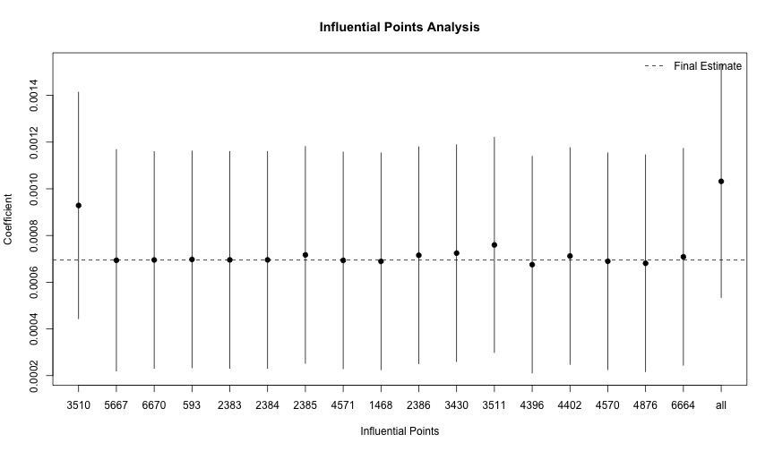

```r
## Plot results
exposureTerm <- grep(d0@exposure, fnames, value = TRUE)
b <- sapply(results, function(x) coef(x)[exposureTerm])
ci <- sapply(results, function(x) confint.default(x, exposureTerm))
xpts <- seq_along(results)
ypts <- b
plot(xpts, ypts, ylim = range(ci), xlab = "Influential Points", ylab = "Coefficient",
    pch = 19, xaxt = "n", main = "Influential Points Analysis")
segments(xpts, ci[1, ], xpts, ci[2, ])
abline(h = coef(final)[exposureTerm], lty = 2)
abline(h = 0, lty = 3, col = "red")
legend("topright", legend = "Final Estimate", lty = 2, bty = "n")
axis(1, xpts, names(results))
```

## Appendix

### Summary of the final fitted model.

```r
print(nyr)
```

```
## [1] 19
```

```r
print(dfmin)
```

```
## [1] 5
```

```r
summary(final)
```

```
##
## Call:
## glm(formula = death ~ dow + ns(date, nyr * dfmin) + ns(tmpd,
##     6) + ns(rmtmpd, 6) + ns(dptp, 3) + ns(rmdptp, 3) + Lag(pm10tmean,
##     1), family = poisson, data = as(d0, "data.frame"))
##
## Deviance Residuals:
##    Min      1Q  Median      3Q     Max
## -3.461  -0.683  -0.039   0.669   4.416
##
## Coefficients: (2 not defined because of singularities)
##                          Estimate Std. Error z value Pr(>|z|)
## (Intercept)              5.503965   0.059088   93.15  < 2e-16
## dowMonday                0.015388   0.008357    1.84  0.06556
## dowSaturday             -0.010907   0.008315   -1.31  0.18962
## dowSunday               -0.015101   0.008305   -1.82  0.06902
## dowThursday             -0.008487   0.008264   -1.03  0.30440
## dowTuesday               0.004280   0.008312    0.51  0.60665
## dowWednesday            -0.009176   0.008224   -1.12  0.26457
## ns(date, nyr * dfmin)1  -0.066276   0.053632   -1.24  0.21655
## ns(date, nyr * dfmin)2  -0.270448   0.071948   -3.76  0.00017
## ns(date, nyr * dfmin)3   0.090100   0.060524    1.49  0.13657
## ns(date, nyr * dfmin)4  -0.154098   0.060425   -2.55  0.01077
## ns(date, nyr * dfmin)5   0.214739   0.058726    3.66  0.00026
## ns(date, nyr * dfmin)6  -0.298046   0.063531   -4.69  2.7e-06
## ns(date, nyr * dfmin)7  -0.093790   0.067956   -1.38  0.16754
## ns(date, nyr * dfmin)8  -0.144898   0.063229   -2.29  0.02193
## ns(date, nyr * dfmin)9   0.081213   0.059486    1.37  0.17218
## ns(date, nyr * dfmin)10 -0.062613   0.059720   -1.05  0.29443
## ns(date, nyr * dfmin)11 -0.167607   0.063785   -2.63  0.00860
## ns(date, nyr * dfmin)12 -0.168059   0.067445   -2.49  0.01271
## ns(date, nyr * dfmin)13 -0.171616   0.062916   -2.73  0.00638
## ns(date, nyr * dfmin)14  0.160479   0.058870    2.73  0.00641
## ns(date, nyr * dfmin)15 -0.179847   0.060710   -2.96  0.00305
## ns(date, nyr * dfmin)16 -0.109682   0.063254   -1.73  0.08292
## ns(date, nyr * dfmin)17 -0.249679   0.069367   -3.60  0.00032
## ns(date, nyr * dfmin)18 -0.174785   0.062511   -2.80  0.00517
## ns(date, nyr * dfmin)19  0.052691   0.059834    0.88  0.37852
## ns(date, nyr * dfmin)20 -0.193851   0.061207   -3.17  0.00154
## ns(date, nyr * dfmin)21 -0.108019   0.064443   -1.68  0.09370
```

[output cut: 87 more lines]

```
## ns(dptp, 3)2            -0.022449   0.063684   -0.35  0.72446
## ns(dptp, 3)3             0.016517   0.025382    0.65  0.51522
## ns(rmdptp, 3)1          -0.047993   0.031044   -1.55  0.12212
## ns(rmdptp, 3)2          -0.070639   0.079507   -0.89  0.37429
## ns(rmdptp, 3)3          -0.134960   0.032597   -4.14  3.5e-05
## Lag(pm10tmean, 1)        0.000696   0.000237    2.94  0.00333
##
## (Dispersion parameter for poisson family taken to be 1)
##
##     Null deviance: 4402.6  on 1123  degrees of freedom
## Residual deviance: 1303.5  on 1005  degrees of freedom
##   (5816 observations deleted due to missingness)
## AIC: 9460
##
## Number of Fisher Scoring iterations: 4
```

SHA-1 hashes for the input data file and the original data frame.

```
## 'ny.rds': 94c5e1cee7a5fdfbc2877475f0e82d014173efae
```

```
## data frame: 80a0c0736fc1bf377afc9acf91bae71a631a9d4d
```

This analysis started on 2013-07-15 16:52:29 and was completed on 2013-07-15 16:53:15.